# Autocorrelação espacial

Dr. Wilson Frantine-Silva

A autocorrelação espacial pode trazer alguns problemas para nossos modelos de nicho, inflando de forma indesejada os modelos e incluindo o ruído proveniente do viés associado.

Nestes casos, podemos utilizar algumas estratégias para escapar desse problema. São basicamentes duas categorias, filtragem e informação de viés. Vamos explorar alguns exemplos e comparações dessas idéias nas próximas páginas

## Preparando o ambiente

### Carregando pacotes

Seguindo a lógica de programação, é sempre importante carregar antes, pacotes e variáveis que iremos utilizar. Nenhum objeto será reconhecido a não ser que tenha sido definido antes, então:

```r
library("data.table")
library("spThin")
library("maptools")
library("ggplot2")
library("MASS")
library("raster")
```

### Setando o diretório

Crie o hábito de setar diretórios onde irá trabalhar. Tudo fica mais fácil de ser encontrado depois.

```r
setwd("/media/wilson/MIDGARD/Documents/Academico/AARE - MNE/Aula 8 - Autocorrelacao/")
```

### Carregando dados de ocorrência

Neste exercício usaremos os dados disponíveis no pacote `spThin` que acabamos de carregar, com occorrências de *Heteromys anomalus*, um “camundongo de bolso” que também ocorre no norte da América do Sul. Para isso, basta digitar o seguinte:

```r
#Carregando os dados na meória:
#veja na aba environment do seu Rstudio, ou digite o comando ls()
data("Heteromys_anomalus_South_America")
#agora atribuiremos esse dado à um objeto chamado `df`, apenas para ficar mais fácil de trabalhar
df <- Heteromys_anomalus_South_America
#Repare que chamamos o objeto agora sem aspas pois ele já está carregado na memória global do ambiente.
#Com os dois próximos comandos veros e cabeçalho e um resumo das variáveis.
head(df)
```

```
##       SPEC       LAT      LONG   REGION
## 1 anomalus  7.883333 -75.20000 mainland
## 2 anomalus  8.000000 -76.73333 mainland
## 3 anomalus 10.616667 -75.03333 mainland
## 4 anomalus  8.633333 -74.06667 mainland
## 5 anomalus  9.966667 -75.06667 mainland
## 6 anomalus 10.216667 -73.38333 mainland
```

```r
summary(df)
```

```
##        SPEC          LAT              LONG             REGION
##  anomalus:201   Min.   : 7.717   Min.   :-76.73   mainland:174
##                 1st Qu.: 9.500   1st Qu.:-71.70   mar     :  2
##                 Median :10.300   Median :-67.92   tobago  :  4
##                 Mean   :10.027   Mean   :-68.02   trin    : 21
##                 3rd Qu.:10.600   3rd Qu.:-63.92
##                 Max.   :11.317   Max.   :-60.53
```

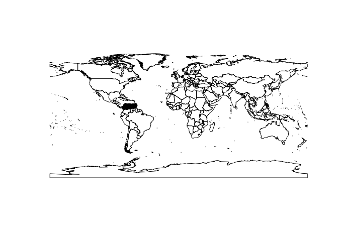

```
## integer(0)
```

```r
#preparando dados para ggplot
data("wrld_simpl")
plot(wrld_simpl)+points(df$LONG, df$LAT)
```

Neste plot podemos ver que os pontos estão todos concentrados na porção superior da América do Sul.

> Dica: você pode alterar o zoom do plot utilizando os parâmetros `xlim` e `ylim` na função `plot`, ou plotando primeiro os pontos e depois o mapa mundi, assim:  
> `plot(df$LONG, df$LAT)+ plot(wrld_simpl, add=T)`

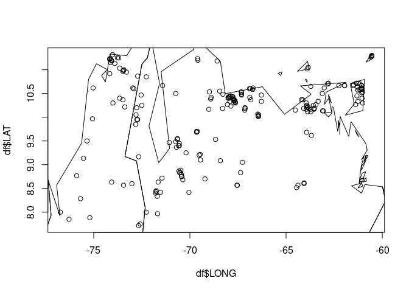

```
## integer(0)
```

```r
plot(df$LONG, df$LAT)+
  plot(wrld_simpl, add=T)
```

Podemos deixar esse plot mais apresentável com o código abaixo, via ggplot.

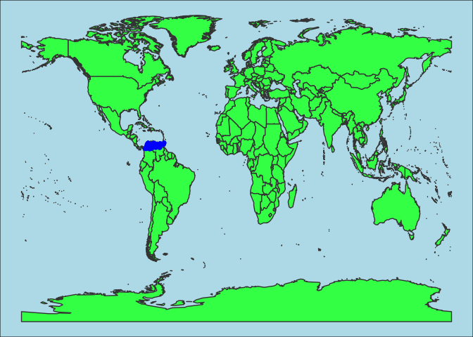

```r
shape_df<-fortify(wrld_simpl)#preparamos os dados para o ggplot2

#plotando...
#nessa linha criamos um objeto chamado fig1 o qual sempre chamara esse plot que estamos fazendo agora.
fig1<-ggplot()+
  #plotamos o mapa
  geom_polygon(data = shape_df , aes(x = long, y = lat, group = group), fill = '#33FF44', color = '#333333')+
  #agora os pontos
  geom_point(data = df, aes(x = LONG, y = LAT), color="blue")+
  #usamos um tema sem linhas ou grades
  theme_void()+
  #adicionanmos o "mar" como retângulo de fundo azul
  theme(panel.background = element_rect('light blue'))
#chamamos fig1
fig1
```

Para observa a área mais de perto com ggplot, criamos os limítes do plot de acordo com os pontos de plotagem. Note que será útil que a extenção seja um pouco maior que as coordenadas precisas de cada ponto, para garantir que todos os pontos aparecerão no plot sem serem cortados

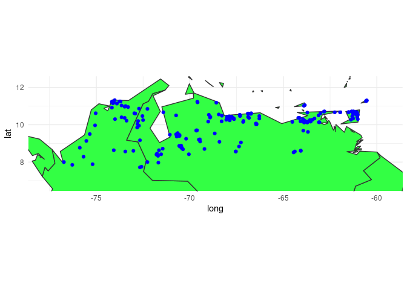

```r
#objeto para estocar os valores de limite no seguinte
#formato: xmin, xmax, ymin, ymax.
ext<-c(range(df$LONG)+c(-1,+1), range(df$LAT)+c(-1,+1))
#Note que `range` retorna o maximo e mínimo de cada coluna, mas como queremos ampliar os limites um pouco, pediremos ao R para somar -1 ao mínimo e +1 ao máximo de cada coluna.

#Para plotar agora basta o seguinte:
fig1+
  coord_equal(xlim=ext[1:2], ylim=ext[3:4])+
  theme_minimal()
```

Agora que temos os pontos e a área devidamante verificadas, vamos as estratégias para eliminar a autocorrelação espacial:

## Estratégia 1: arquivo bias (viés)

Nesse estratégia criaremos uma camada dizendo onde o viés se concentra, mas para isso precisaremos de um raster de referência para criar alguns parâmetros. Lembre-se que esse raster deve ser as mesmas camadas que você vai utilizar para a modelagem.